# 第1章 R概述

武汉大学经济与管理学院  
刘开军 博士  
Email: kjliu@whu.edu.cn

## 这门的目的

相关理论课程：

- 高等数学I、II
- 概率论、数理统计
- 计量经济学
- 管理研究方法论
- ……

学习了这么多的理论，你会动手解决问题吗？

本课程的目的**用计算机工具实现数据分析理论，让你能动手**。

## 为什么选择R

- R是免费的开源软件
- R能跨平台，可以在Windows、Linux、MacOS等平台上运行
- R功能统计分析功能强大
- R拥有顶尖水准的制图功能
- R可与其他编程言结合，包括C/C++、Java、Python等；
- $\cdots\cdots\cdots$

## R是什么

1. 计算工具
2. 统计分析工具
3. 绘图工具

## (1)计算工具

```r
2+7
```

```
## [1] 9
```

```r
#使用R内置的函数
10+20.1/3+sqrt(2)
```

```
## [1] 18.11421
```

```r
#计算1+2+...+100
a<-c(1:100); sum(a)
```

```
## [1] 5050
```

从简单的1+2=3，到复杂的数值方程计算，都可以用R完成。

我们可以把R当成一个“超级”计算器。

## (2)统计分析工具

统计分析是R最主要的用途，通常认为R是一种**统计分析软件**。

```r
mydata<-rnorm(100, mean=10, sd=2)
summary(mydata)
```

```
##    Min. 1st Qu.  Median    Mean 3rd Qu.    Max.
##   3.910   8.445   9.573   9.620  10.831  14.774
```

```r
lm(mpg~wt, data=mtcars)
```

```
##
## Call:
## lm(formula = mpg ~ wt, data = mtcars)
##
## Coefficients:
## (Intercept)           wt
##      37.285       -5.344
```

由于R是开源软件，由全球数以万计的程序员来维护，所以几乎可以在R中找到所有的统计分析工具。

**在统计领域，只有你想不到，没有R做不到。**

## (3)绘图工具

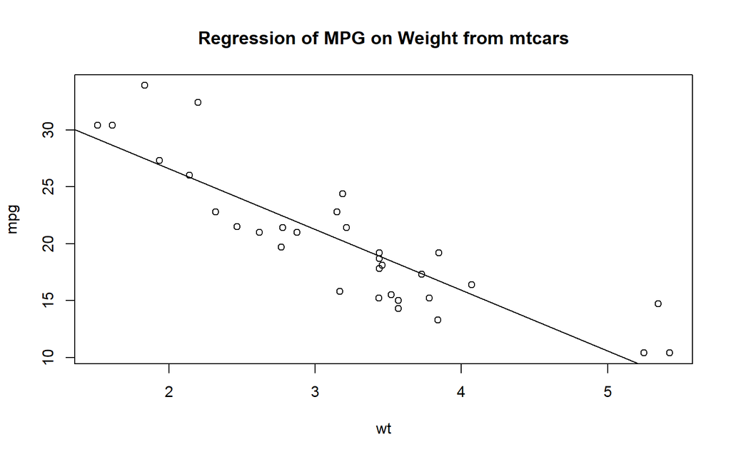

## 安装R

首先，需要安装R软件。R软件及众多的扩展包都可以从 http://cran.r-project.org 下载。

安装完成后，可以在开始菜单中找到RGui.exe，这个程序可以打开R控制台(R Console)，然后在此执行交互式工作，即输入一条命令，等待R输出结果；再输入一条命令，等待R输出结果；…..

如果要完成更复杂的工作，需要安装RStudio软件。RStudio以R控制台为基础，并提供了编写脚本、调试等功能，是R程序员常用的工作平台。

本课程的工作都可在RGui或RStudio完成。

## 初识RGui

运行RGui，输入以下命令，看看结果。

```r
2+7
10+20.1/3+sqrt(2)

x <- pretty(-3:3, 30)
y <- dnorm(x)
plot(x, y)
```

试一试上、下方向键。

## 第1个操作符

R最常用的操作符是**赋值符**`<-`，通常的写法是：

```r
varible <- expression  #将expression的结果保存在variable中
variable               #查看variable的值
```

“`variable <- expression`”表示把表达式`expression`的计算结果保存在变量`variable中`。在控制台中，直接输入变量名`vairable`，将输出变量当前的值。例如：

```r
workmates <- c("Zhou", "Zhang", "Yang")
workmates
```

```
## [1] "Zhou"  "Zhang" "Yang"
```

**注释**是以`#`开始的文本，在`#`之后的文字都会被R当作注释而被忽略。如果有一段代码暂时不需要，可以用注释符把它们屏蔽。

## 最重要的技能

R有数以千计的函数，为数众多的包，你不可能把这些全都记作。所以在编写程序时，需要经常查帮助文档。

| 函数 | 功能 |
| --- | --- |
| help.start() | 打开帮助文档系统的首页 |
| help(“keyword”) 或 ? keyword | 查看keyword的帮助 |
| help.search(“keyword”) 或 ?? keyword | 搜索含有keyword的帮助文档 |

当然，最强大的帮助系统当属度娘和谷哥。

## 一个例子

在RGui.exe或RStudio.exe中输入以下语句：

```r
age <- c(1, 3, 5, 2, 11, 9, 3, 9, 12, 3)
weight <- c(4.4, 5.3, 7.2, 5.2, 8.5, 7.3, 6.0, 10.4, 10.2, 6.1)
mean(weight)
sd(weight)
cor(age, weight)
plot(age, weight)
```

用帮助系统，看看上面用到的函数`c, mean, sd, cor, plot`各有何功能。

## 标准的工作步骤

当退出R时，输入的数据将会丢失，下次做计算时需要再次输入，这当然是我们不希望的。通常，我们希望将工作空间中的数据保存下来，下次计算时再载入这些数据，之后继续计算。

标准工作步骤：

1. 为每个数据分析任务建立一个专门的目录，将所有的数据、文档、程序等资料都放入这个目录；
2. 每次打开RGui或RStudio时，首先载入数据文件；
3. 进行计算；
4. 在退出之前，保存数据。

使用到的函数：

| 函数 | 功能 |
| --- | --- |
| save.image(filename) | 将当前工作空间中的数据保存为filename指定的文件 |
| load(filename) | 将filename指定的数据文件载入到当前工作空间 |
| ls() | 列出当前工作空间中的变量 |
| rm(variable) | 删除变量variable |

注意，filename中的路径分隔符是`/`，而不是常用的`\`。R的数据文件名的后缀通常取为RData。例如：

```r
load("E:/myproject/mydata.RData")   #或者load("E:\\myproject\\mydata.RData")
#
# 做各种计算
#
save.image("E:/myproject/mydata.RData")  #或者save.image("E:\\myproject\\mydata.RData")
q()
```

## 安装和使用包（暂时用不上）

R的数以千计的函数被分成很多组，每个组就是一个包（package）。R的包是数据、函数、预编译代码的集合。

当安装R时，会默认安装一些最常用的包。可以用`library()`查看所有已经安装的包。

除了这些最常用的包，你还可以安装其他包，执行函数`install.packages(package_name)`。一个包只需要安装一次。

在需要使用一个包时，使用`library(package_name)`加载包，之后这个包所包含的函数就可以直接使用了。

例如：

```r
install.packages("vcd")
```

这样就把vcd包安装到了R系统，你可以在R的安装目录下找到它。

```r
library("vcd")
help("vcd")
example(Arthritis)
```

## Do It Yourself

- 看帮助文档，找出常用的数学函数；
- 求方程$2x^2-6x+3=0$的根；
- 试一试保存数据、加载数据；
- 查看函数`data()和search()`的功能；

课后作业：安装R和RStudio